# Germination Experiment

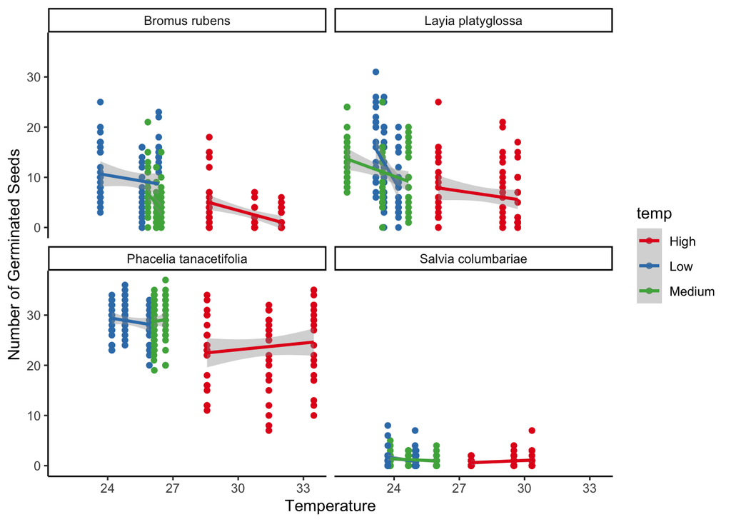

```r
###Figure shows temperature v Germination in 6 weeks, facet by species and filled via temperature
TempspeciesFacetColor <- ggplot(final, aes(mean_temp, germination, color = temp),show.legend=FALSE) +
  geom_point() +
  facet_wrap(~species)+
  scale_color_brewer(palette = "Set1") + theme_classic() +
  geom_smooth(method = lm, se = TRUE) +
  labs(x = "Temperature", y = "Number of Germinated Seeds")
TempspeciesFacetColor
```

```r
###Statistics For Germination of Each species at varying temperatures
m1 <- glm(germination ~ temp*species+mean_temp, family = "quasipoisson", data = final)
anova(m1, test = "Chisq")
```

```
## Analysis of Deviance Table
##
## Model: quasipoisson, link: log
##
## Response: germination
##
## Terms added sequentially (first to last)
##
##
##              Df Deviance Resid. Df Resid. Dev  Pr(>Chi)
## NULL                           839    10186.2
## temp          2    275.3       837     9910.9 < 2.2e-16 ***
## species       3   7283.5       834     2627.4 < 2.2e-16 ***
## mean_temp     1     10.1       833     2617.3   0.06068 .
## temp:species  6    208.3       827     2409.0 1.321e-13 ***
## ---
## Signif. codes:  0 '***' 0.001 '**' 0.01 '*' 0.05 '.' 0.1 ' ' 1
```

```r
###Was temp manipulated significantly in the experiment?
e1 <- emmeans(m1, pairwise~temp)
```

```
## NOTE: Results may be misleading due to involvement in interactions
```

```r
e1
```

```
## $emmeans
##  temp   emmean     SE  df asymp.LCL asymp.UCL
##  High     1.62 0.0824 Inf      1.46      1.78
##  Low      1.97 0.0614 Inf      1.85      2.09
##  Medium   1.83 0.0590 Inf      1.71      1.94
##
## Results are averaged over the levels of: species
## Results are given on the log (not the response) scale.
## Confidence level used: 0.95
##
## $contrasts
##  contrast      estimate     SE  df z.ratio p.value
##  High - Low      -0.351 0.1164 Inf  -3.015  0.0072
##  High - Medium   -0.206 0.1113 Inf  -1.851  0.1533
##  Low - Medium     0.145 0.0771 Inf   1.879  0.1449
##
## Results are averaged over the levels of: species
## Results are given on the log (not the response) scale.
## P value adjustment: tukey method for comparing a family of 3 estimates
```

```r
###Germination by temp and species
e2 <- emmeans(m1, pairwise~temp|species) ###Low Temp brome germinates the same amount as Layia at all temps
e2
```

```
## $emmeans
## species = Bromus rubens:
##  temp    emmean     SE  df asymp.LCL asymp.UCL
##  High    1.2080 0.1355 Inf     0.943     1.474
##  Low     2.1947 0.0691 Inf     2.059     2.330
##  Medium  1.5953 0.0908 Inf     1.417     1.773
##
## species = Layia platyglossa:
##  temp    emmean     SE  df asymp.LCL asymp.UCL
##  High    1.9438 0.0836 Inf     1.780     2.108
##  Low     2.3695 0.0736 Inf     2.225     2.514
##  Medium  2.2819 0.0788 Inf     2.127     2.436
##
## species = Phacelia tanacetifolia:
##  temp    emmean     SE  df asymp.LCL asymp.UCL
##  High    3.3623 0.0817 Inf     3.202     3.522
##  Low     3.2934 0.0449 Inf     3.205     3.381
##  Medium  3.3526 0.0379 Inf     3.278     3.427
##
## species = Salvia columbariae:
##  temp    emmean     SE  df asymp.LCL asymp.UCL
##  High   -0.0246 0.2208 Inf    -0.457     0.408
##  Low     0.0355 0.1933 Inf    -0.343     0.414
##  Medium  0.0837 0.1892 Inf    -0.287     0.455
##
## Results are given on the log (not the response) scale.
## Confidence level used: 0.95
##
## $contrasts
## species = Bromus rubens:
##  contrast      estimate     SE  df z.ratio p.value
##  High - Low    -0.98667 0.1604 Inf  -6.152  <.0001
##  High - Medium -0.38724 0.1650 Inf  -2.347  0.0496
##  Low - Medium   0.59943 0.1131 Inf   5.298  <.0001
##
## species = Layia platyglossa:
##  contrast      estimate     SE  df z.ratio p.value
##  High - Low    -0.42574 0.1214 Inf  -3.508  0.0013
##  High - Medium -0.33812 0.1257 Inf  -2.690  0.0195
##  Low - Medium   0.08762 0.0841 Inf   1.042  0.5501
##
## species = Phacelia tanacetifolia:
##  contrast      estimate     SE  df z.ratio p.value
##  High - Low     0.06895 0.1100 Inf   0.627  0.8054
##  High - Medium  0.00973 0.0925 Inf   0.105  0.9939
##  Low - Medium  -0.05922 0.0574 Inf  -1.031  0.5572
##
## species = Salvia columbariae:
##  contrast      estimate     SE  df z.ratio p.value
##  High - Low    -0.06010 0.2976 Inf  -0.202  0.9778
##  High - Medium -0.10830 0.2945 Inf  -0.368  0.9282
##  Low - Medium  -0.04819 0.2674 Inf  -0.180  0.9823
##
## Results are given on the log (not the response) scale.
## P value adjustment: tukey method for comparing a family of 3 estimates
```

```r
###Difference in germination by species and temp
e3 <- emmeans(m1, pairwise~species|temp) ###Low Temp brome germinates the same amount as Layia at all temps
e3
```

```
## $emmeans
## temp = High:
##  species                 emmean     SE  df asymp.LCL asymp.UCL
##  Bromus rubens           1.2080 0.1355 Inf     0.943     1.474
##  Layia platyglossa       1.9438 0.0836 Inf     1.780     2.108
##  Phacelia tanacetifolia  3.3623 0.0817 Inf     3.202     3.522
##  Salvia columbariae     -0.0246 0.2208 Inf    -0.457     0.408
##
## temp = Low:
##  species                 emmean     SE  df asymp.LCL asymp.UCL
##  Bromus rubens           2.1947 0.0691 Inf     2.059     2.330
##  Layia platyglossa       2.3695 0.0736 Inf     2.225     2.514
##  Phacelia tanacetifolia  3.2934 0.0449 Inf     3.205     3.381
##  Salvia columbariae      0.0355 0.1933 Inf    -0.343     0.414
##
## temp = Medium:
##  species                 emmean     SE  df asymp.LCL asymp.UCL
##  Bromus rubens           1.5953 0.0908 Inf     1.417     1.773
##  Layia platyglossa       2.2819 0.0788 Inf     2.127     2.436
##  Phacelia tanacetifolia  3.3526 0.0379 Inf     3.278     3.427
##  Salvia columbariae      0.0837 0.1892 Inf    -0.287     0.455
##
## Results are given on the log (not the response) scale.
## Confidence level used: 0.95
##
## $contrasts
## temp = High:
##  contrast                                    estimate     SE  df z.ratio
##  Bromus rubens - Layia platyglossa             -0.736 0.1490 Inf  -4.937
##  Bromus rubens - Phacelia tanacetifolia        -2.154 0.1281 Inf -16.811
##  Bromus rubens - Salvia columbariae             1.233 0.2494 Inf   4.942
##  Layia platyglossa - Phacelia tanacetifolia    -1.419 0.1003 Inf -14.138
##  Layia platyglossa - Salvia columbariae         1.968 0.2317 Inf   8.494
##  Phacelia tanacetifolia - Salvia columbariae    3.387 0.2232 Inf  15.174
##  p.value
##   <.0001
##   <.0001
##   <.0001
##   <.0001
##   <.0001
```

[output cut: 21 more lines]

```
##  Bromus rubens - Phacelia tanacetifolia        -1.757 0.0982 Inf -17.889
##  Bromus rubens - Salvia columbariae             1.512 0.2092 Inf   7.224
##  Layia platyglossa - Phacelia tanacetifolia    -1.071 0.0856 Inf -12.511
##  Layia platyglossa - Salvia columbariae         2.198 0.1982 Inf  11.089
##  Phacelia tanacetifolia - Salvia columbariae    3.269 0.1926 Inf  16.977
##  p.value
##   <.0001
##   <.0001
##   <.0001
##   <.0001
##   <.0001
##   <.0001
##
## Results are given on the log (not the response) scale.
## P value adjustment: tukey method for comparing a family of 4 estimates
```

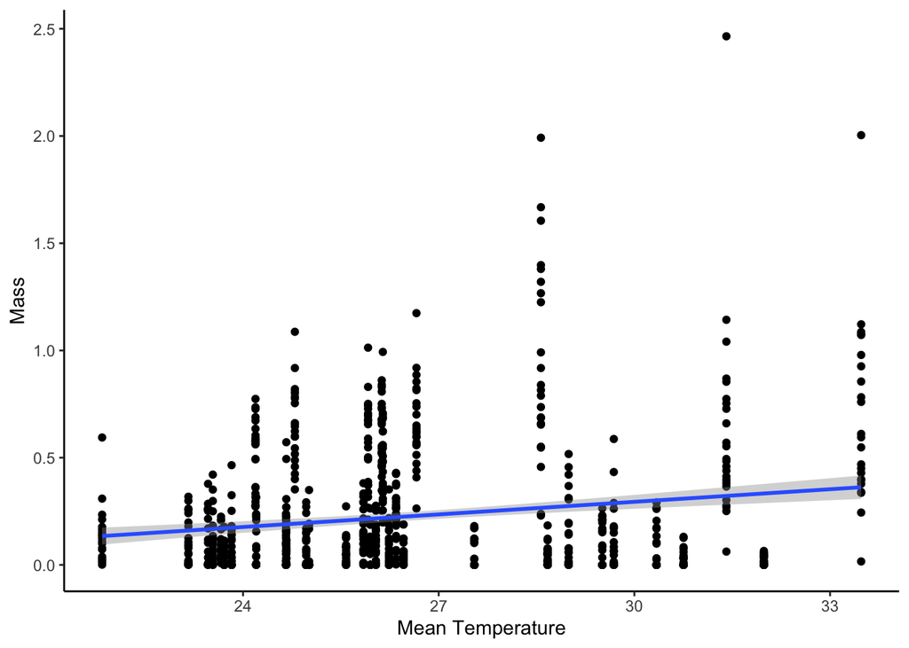

```r
###Mass by Temperature
Mass <- ggplot(final, aes(mean_temp, mass),show.legend=FALSE) +
  geom_point() +
  scale_color_brewer(palette = "Set1") + theme_classic() +
  theme() +
  geom_smooth(method = lm, se = TRUE) +
  labs(x = "Mean Temperature", y = "Mass")
Mass
```

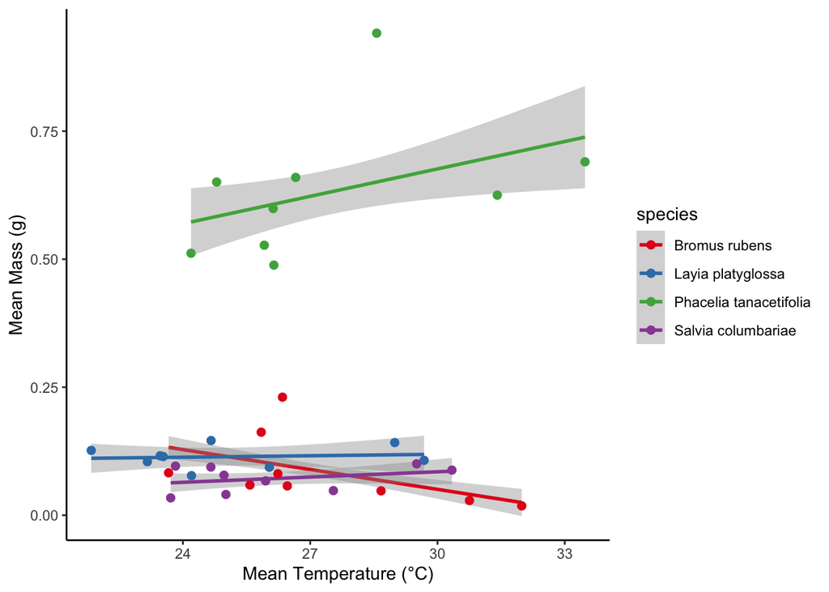

```r
MassSpecies <- ggplot(final, aes(mean_temp, mass, color = species),show.legend=FALSE) +
   geom_smooth(method = lm, se = TRUE) +
  scale_color_brewer(palette = "Set1") + theme_classic() +
  stat_summary(fun.y=mean, geom="point", size=2)+
  labs(x = "Mean Temperature (°C)", y = "Mean Mass (g)")
MassSpecies
```

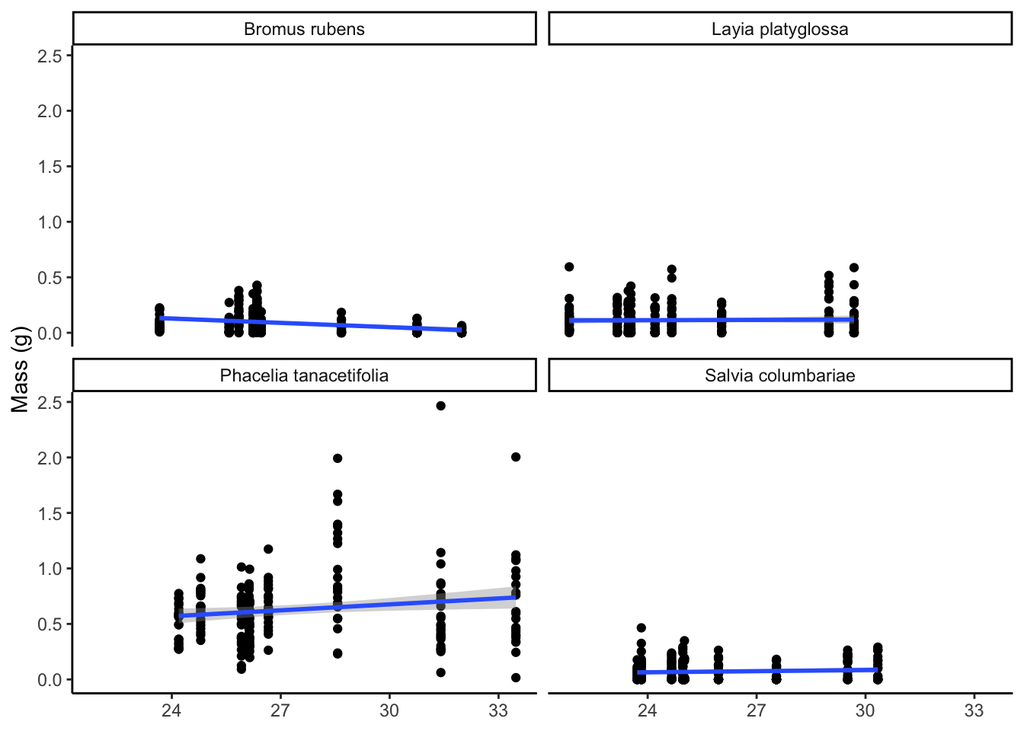

```r
MassSpeciesFacet <- ggplot(final, aes(mean_temp, mass),show.legend=FALSE) +
  geom_point() +
  facet_wrap(~species)+
  scale_color_brewer(palette = "Set1") + theme_classic() +
  theme(axis.title.x = element_blank()) +
  geom_smooth(method = lm, se = TRUE) +
  labs(x = "Temperature", y = "Mass (g)")
MassSpeciesFacet
```

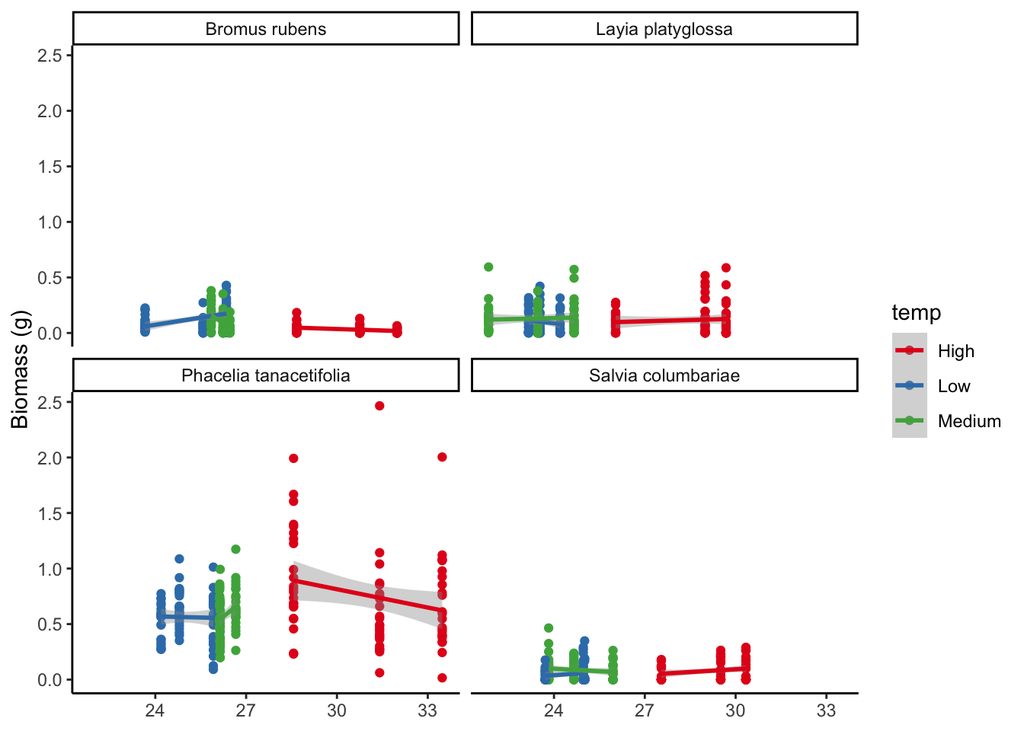

```r
###Temperature v biomass, facet by species and fill by Temp
MassSpeciesFacetColor <- ggplot(final, aes(mean_temp, mass, color = temp),show.legend=FALSE) +
  geom_point() +
  facet_wrap(~species)+
  scale_color_brewer(palette = "Set1") + theme_classic() +
  theme(axis.title.x = element_blank()) +
  geom_smooth(method = lm, se = TRUE) +
  labs(x = "Temperature", y = "Biomass (g)")
MassSpeciesFacetColor
```

```r
###Biomass by temp and species
m2 <- glm(mass ~ germination*temp*species+mean_temp, family = "quasipoisson", data = final)
anova(m2, test = "Chisq")
```

```
## Analysis of Deviance Table
##
## Model: quasipoisson, link: log
##
## Response: mass
##
## Terms added sequentially (first to last)
##
##
##                          Df Deviance Resid. Df Resid. Dev  Pr(>Chi)
## NULL                                       839    277.763
## germination               1  158.031       838    119.732 < 2.2e-16 ***
## temp                      2    8.172       836    111.560 < 2.2e-16 ***
## species                   3   12.950       833     98.611 < 2.2e-16 ***
## mean_temp                 1    0.273       832     98.338    0.1013
## germination:temp          2    3.104       830     95.234 2.329e-07 ***
## germination:species       3   11.017       827     84.217 < 2.2e-16 ***
## temp:species              6    3.673       821     80.544 2.583e-06 ***
## germination:temp:species  6    0.543       815     80.000    0.5001
## ---
## Signif. codes:  0 '***' 0.001 '**' 0.01 '*' 0.05 '.' 0.1 ' ' 1
```

```r
e4 <- emmeans(m2, pairwise~temp|species)
```

```
## NOTE: Results may be misleading due to involvement in interactions
```

```r
e4
```

```
## $emmeans
## species = Bromus rubens:
##  temp   emmean    SE  df asymp.LCL asymp.UCL
##  High   -2.531 0.276 Inf   -3.0715    -1.990
##  Low    -2.111 0.113 Inf   -2.3328    -1.888
##  Medium -1.872 0.151 Inf   -2.1675    -1.577
##
## species = Layia platyglossa:
##  temp   emmean    SE  df asymp.LCL asymp.UCL
##  High   -1.892 0.116 Inf   -2.1195    -1.665
##  Low    -2.519 0.147 Inf   -2.8064    -2.231
##  Medium -2.289 0.136 Inf   -2.5556    -2.022
##
## species = Phacelia tanacetifolia:
##  temp   emmean    SE  df asymp.LCL asymp.UCL
##  High   -0.527 0.124 Inf   -0.7704    -0.284
##  Low    -0.392 0.268 Inf   -0.9178     0.134
##  Medium -0.279 0.216 Inf   -0.7018     0.144
##
## species = Salvia columbariae:
##  temp   emmean    SE  df asymp.LCL asymp.UCL
##  High    1.123 0.596 Inf   -0.0446     2.291
##  Low    -1.227 0.702 Inf   -2.6019     0.149
##  Medium  1.299 0.842 Inf   -0.3517     2.950
##
## Results are given on the log (not the response) scale.
## Confidence level used: 0.95
##
## $contrasts
## species = Bromus rubens:
##  contrast      estimate    SE  df z.ratio p.value
##  High - Low      -0.420 0.303 Inf  -1.389  0.3467
##  High - Medium   -0.659 0.316 Inf  -2.087  0.0925
##  Low - Medium    -0.238 0.187 Inf  -1.271  0.4115
##
## species = Layia platyglossa:
##  contrast      estimate    SE  df z.ratio p.value
##  High - Low       0.627 0.195 Inf   3.214  0.0037
##  High - Medium    0.397 0.188 Inf   2.111  0.0875
##  Low - Medium    -0.230 0.184 Inf  -1.250  0.4234
##
## species = Phacelia tanacetifolia:
##  contrast      estimate    SE  df z.ratio p.value
##  High - Low      -0.136 0.300 Inf  -0.451  0.8938
##  High - Medium   -0.249 0.250 Inf  -0.994  0.5809
##  Low - Medium    -0.113 0.344 Inf  -0.329  0.9422
##
## species = Salvia columbariae:
##  contrast      estimate    SE  df z.ratio p.value
##  High - Low       2.350 0.925 Inf   2.539  0.0299
##  High - Medium   -0.176 1.036 Inf  -0.170  0.9843
##  Low - Medium    -2.526 1.094 Inf  -2.309  0.0545
##
## Results are given on the log (not the response) scale.
## P value adjustment: tukey method for comparing a family of 3 estimates
```

```r
###Difference in biomass by species and temp
e5 <- emmeans(m2, pairwise~species|temp)
```

```
## NOTE: Results may be misleading due to involvement in interactions
```

```r
e5
```

```
## $emmeans
## temp = High:
##  species                emmean    SE  df asymp.LCL asymp.UCL
##  Bromus rubens          -2.531 0.276 Inf   -3.0715    -1.990
##  Layia platyglossa      -1.892 0.116 Inf   -2.1195    -1.665
##  Phacelia tanacetifolia -0.527 0.124 Inf   -0.7704    -0.284
##  Salvia columbariae      1.123 0.596 Inf   -0.0446     2.291
##
## temp = Low:
##  species                emmean    SE  df asymp.LCL asymp.UCL
##  Bromus rubens          -2.111 0.113 Inf   -2.3328    -1.888
##  Layia platyglossa      -2.519 0.147 Inf   -2.8064    -2.231
##  Phacelia tanacetifolia -0.392 0.268 Inf   -0.9178     0.134
##  Salvia columbariae     -1.227 0.702 Inf   -2.6019     0.149
##
## temp = Medium:
##  species                emmean    SE  df asymp.LCL asymp.UCL
##  Bromus rubens          -1.872 0.151 Inf   -2.1675    -1.577
##  Layia platyglossa      -2.289 0.136 Inf   -2.5556    -2.022
##  Phacelia tanacetifolia -0.279 0.216 Inf   -0.7018     0.144
##  Salvia columbariae      1.299 0.842 Inf   -0.3517     2.950
##
## Results are given on the log (not the response) scale.
## Confidence level used: 0.95
##
## $contrasts
## temp = High:
##  contrast                                    estimate    SE  df z.ratio p.value
##  Bromus rubens - Layia platyglossa             -0.639 0.294 Inf  -2.171  0.1314
##  Bromus rubens - Phacelia tanacetifolia        -2.004 0.289 Inf  -6.933  <.0001
##  Bromus rubens - Salvia columbariae            -3.654 0.650 Inf  -5.625  <.0001
##  Layia platyglossa - Phacelia tanacetifolia    -1.365 0.157 Inf  -8.689  <.0001
##  Layia platyglossa - Salvia columbariae        -3.015 0.603 Inf  -4.999  <.0001
##  Phacelia tanacetifolia - Salvia columbariae   -1.651 0.598 Inf  -2.761  0.0294
##
## temp = Low:
##  contrast                                    estimate    SE  df z.ratio p.value
##  Bromus rubens - Layia platyglossa              0.408 0.178 Inf   2.290  0.1002
##  Bromus rubens - Phacelia tanacetifolia        -1.719 0.290 Inf  -5.933  <.0001
##  Bromus rubens - Salvia columbariae            -0.884 0.709 Inf  -1.247  0.5969
##  Layia platyglossa - Phacelia tanacetifolia    -2.127 0.303 Inf  -7.026  <.0001
##  Layia platyglossa - Salvia columbariae        -1.292 0.713 Inf  -1.812  0.2677
##  Phacelia tanacetifolia - Salvia columbariae    0.835 0.750 Inf   1.113  0.6816
##
## temp = Medium:
##  contrast                                    estimate    SE  df z.ratio p.value
##  Bromus rubens - Layia platyglossa              0.417 0.201 Inf   2.077  0.1606
##  Bromus rubens - Phacelia tanacetifolia        -1.594 0.263 Inf  -6.058  <.0001
##  Bromus rubens - Salvia columbariae            -3.171 0.855 Inf  -3.709  0.0012
##  Layia platyglossa - Phacelia tanacetifolia    -2.010 0.254 Inf  -7.911  <.0001
##  Layia platyglossa - Salvia columbariae        -3.588 0.849 Inf  -4.224  0.0001
##  Phacelia tanacetifolia - Salvia columbariae   -1.578 0.869 Inf  -1.815  0.2660
##
## Results are given on the log (not the response) scale.
## P value adjustment: tukey method for comparing a family of 4 estimates
```

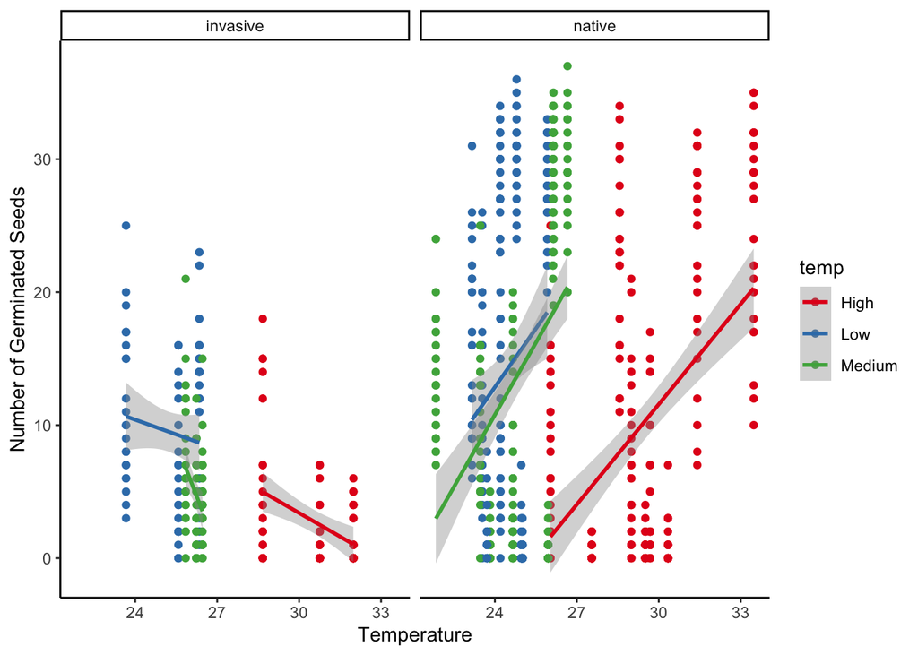

```r
#Natives Vs Invasives Germination
locality <- ggplot(final, aes(mean_temp, germination, color = temp),show.legend=FALSE) +
  geom_point() +
  facet_wrap(~locality) +
  scale_color_brewer(palette = "Set1") + theme_classic() +
  geom_smooth(method = lm, se = TRUE) +
  labs(x = "Temperature", y = "Number of Germinated Seeds")
locality
```

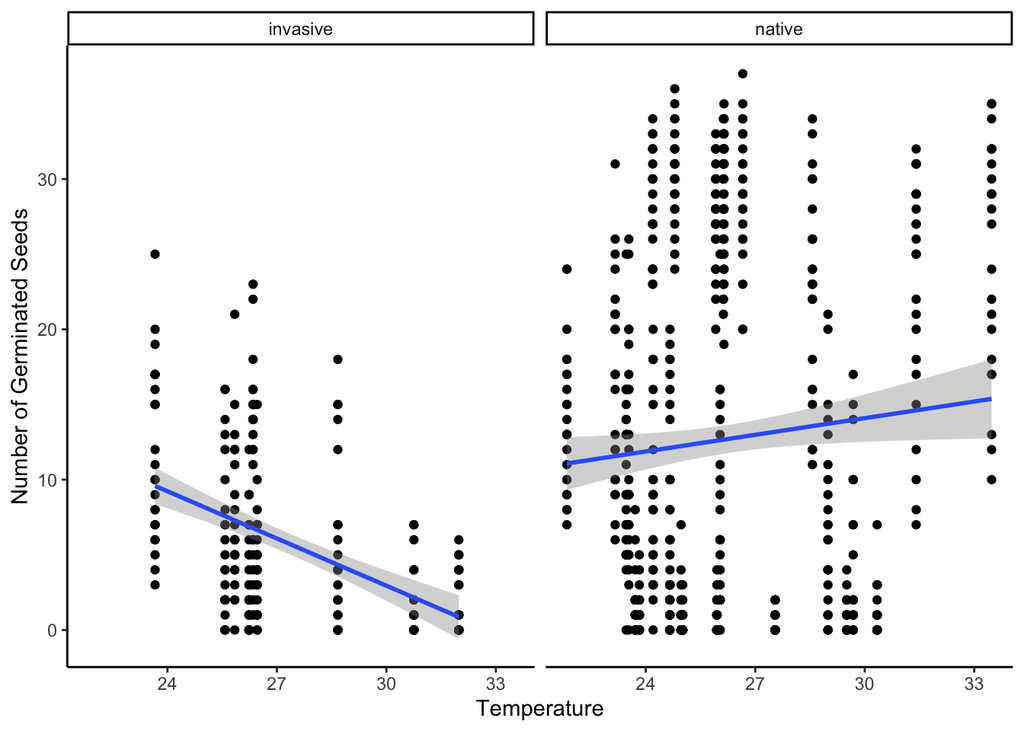

```r
locality2 <- ggplot(final, aes(mean_temp, germination),show.legend=FALSE) +
  geom_point() +
  facet_wrap(~locality) +
  scale_color_brewer(palette = "Set1") + theme_classic() +
  geom_smooth(method = lm, se = TRUE) +
  labs(x = "Temperature", y = "Number of Germinated Seeds")
locality2
```

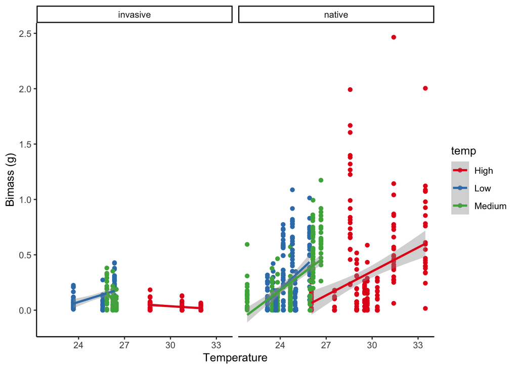

```r
#Native vs Invasive Biomass
locality3 <- ggplot(final, aes(mean_temp, mass, color = temp),show.legend=FALSE) +
  geom_point() +
  facet_wrap(~locality) +
  scale_color_brewer(palette = "Set1") + theme_classic() +
  geom_smooth(method = lm, se = TRUE) +
  labs(x = "Temperature", y = "Bimass (g)")
locality3
```

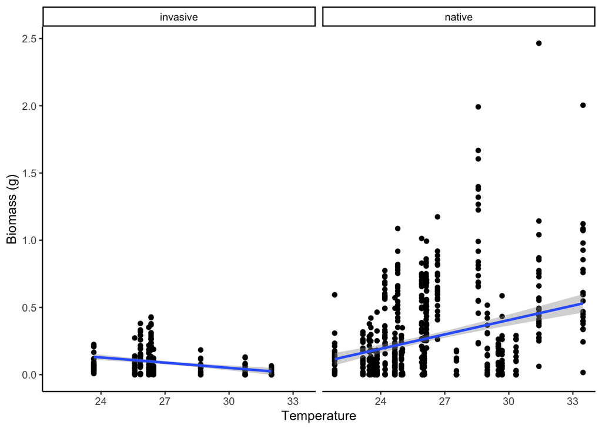

```r
locality4 <- ggplot(final, aes(mean_temp, mass),show.legend=FALSE) +
  geom_point() +
  facet_wrap(~locality) +
  scale_color_brewer(palette = "Set1") + theme_classic() +
  geom_smooth(method = lm, se = TRUE) +
  labs(x = "Temperature", y = "Biomass (g)")
locality4
```

```r
#Natives vs Invasives Stats Mass
m3 <- glm(mass ~ germination*temp*locality, family = "quasipoisson", data = final)
anova(m3, test = "Chisq")
```

```
## Analysis of Deviance Table
##
## Model: quasipoisson, link: log
##
## Response: mass
##
## Terms added sequentially (first to last)
##
##
##                           Df Deviance Resid. Df Resid. Dev  Pr(>Chi)
## NULL                                        839     277.76
## germination                1  158.031       838     119.73 < 2.2e-16 ***
## temp                       2    8.172       836     111.56 1.528e-14 ***
## locality                   1    1.245       835     110.31 0.0018484 **
## germination:temp           2    1.873       833     108.44 0.0006817 ***
## germination:locality       1    0.785       832     107.66 0.0134540 *
## temp:locality              2    3.013       830     104.64 8.047e-06 ***
## germination:temp:locality  2    0.256       828     104.39 0.3692657
## ---
## Signif. codes:  0 '***' 0.001 '**' 0.01 '*' 0.05 '.' 0.1 ' ' 1
```

```r
e6 <- emmeans(m3, pairwise~locality|temp)
```

```
## NOTE: Results may be misleading due to involvement in interactions
```

```r
e6
```

```
## $emmeans
## temp = High:
##  locality emmean     SE  df asymp.LCL asymp.UCL
##  invasive  -2.60 0.3043 Inf     -3.20     -2.01
##  native    -1.54 0.0602 Inf     -1.66     -1.42
##
## temp = Low:
##  locality emmean     SE  df asymp.LCL asymp.UCL
##  invasive  -2.08 0.1243 Inf     -2.32     -1.83
##  native    -2.16 0.0893 Inf     -2.33     -1.98
##
## temp = Medium:
##  locality emmean     SE  df asymp.LCL asymp.UCL
##  invasive  -1.86 0.1691 Inf     -2.19     -1.53
##  native    -1.85 0.0729 Inf     -1.99     -1.70
##
## Results are given on the log (not the response) scale.
## Confidence level used: 0.95
##
## $contrasts
## temp = High:
##  contrast          estimate    SE  df z.ratio p.value
##  invasive - native  -1.0616 0.310 Inf  -3.422  0.0006
##
## temp = Low:
##  contrast          estimate    SE  df z.ratio p.value
##  invasive - native   0.0831 0.153 Inf   0.543  0.5870
##
## temp = Medium:
##  contrast          estimate    SE  df z.ratio p.value
##  invasive - native  -0.0135 0.184 Inf  -0.074  0.9413
##
## Results are given on the log (not the response) scale.
```

```r
m4 <- glm(germination ~ temp*locality, family = "quasipoisson", data = final)
anova(m4, test = "Chisq")
```

```
## Analysis of Deviance Table
##
## Model: quasipoisson, link: log
##
## Response: germination
##
## Terms added sequentially (first to last)
##
##
##               Df Deviance Resid. Df Resid. Dev  Pr(>Chi)
## NULL                            839    10186.2
## temp           2   275.26       837     9910.9 5.772e-07 ***
## locality       1   789.10       836     9121.8 < 2.2e-16 ***
## temp:locality  2   150.97       834     8970.9 0.0003788 ***
## ---
## Signif. codes:  0 '***' 0.001 '**' 0.01 '*' 0.05 '.' 0.1 ' ' 1
```

```r
e7 <- emmeans(m4, pairwise~locality|temp)
e7
```

```
## $emmeans
## temp = High:
##  locality emmean     SE  df asymp.LCL asymp.UCL
##  invasive   1.03 0.2205 Inf     0.603      1.47
##  native     2.33 0.0665 Inf     2.204      2.46
##
## temp = Low:
##  locality emmean     SE  df asymp.LCL asymp.UCL
##  invasive   2.25 0.1199 Inf     2.018      2.49
##  native     2.64 0.0570 Inf     2.529      2.75
##
## temp = Medium:
##  locality emmean     SE  df asymp.LCL asymp.UCL
##  invasive   1.61 0.1655 Inf     1.285      1.93
##  native     2.62 0.0576 Inf     2.509      2.73
##
## Results are given on the log (not the response) scale.
## Confidence level used: 0.95
##
## $contrasts
## temp = High:
##  contrast          estimate    SE  df z.ratio p.value
##  invasive - native   -1.300 0.230 Inf  -5.644  <.0001
##
## temp = Low:
##  contrast          estimate    SE  df z.ratio p.value
##  invasive - native   -0.388 0.133 Inf  -2.921  0.0035
##
## temp = Medium:
##  contrast          estimate    SE  df z.ratio p.value
##  invasive - native   -1.012 0.175 Inf  -5.777  <.0001
##
## Results are given on the log (not the response) scale.
```

###Ideas from Previous version Purpose: The purpose of this experiment is to determine if cooler temperatures, as seen under shrub canopies, could be used as an indicator for the germination success of both native and exotic plant species in arid ecosystems.

Hypothesis: We hypothesize that variations in fine scale temperature can act as a direct proxy for successful desert plant establishment and germination.

Predictions: 1) Fine scale temperature can be experimentally manipulated via heat lamps in an enclosed setting. 2) Plants will respond to varying fine scale temperatures. 3) The response to temperature will be species specific. 4) Responses to temperature will vary between native and exotic plant species.

Data: All data can be access on KNB. https://knb.ecoinformatics.org/view/doi:10.5063/F1GQ6W6R

Rough Ideas: 1)To connect this to shrub density I want to show that the cooler temperatures, as experienced under shrubs, can provide a benefit for species germination. The law table is meant to simulate these lower temperatures while the medium and high tables are meant to act as open areas at a moderate temperature and at extreme temperature. 2)There should be a visible difference between overall germination and mass between native and invasive species. If we can determine if invasives can germinate better under shrubs than in open areas then we can connect this to competition between natives and invasive. 3)Species should vary in their response to fine scale temperature since the range that they germinate vary from species to species. We should see that some natives germinate better at specific temperature while others do not. 4) We can connect this possibly to climate change. If we find that higher temperatures means a lower germination success then that can be the take-home message, that increasing temperatures have negative effects on desert plant species.